# Maths Grades Analysis

| Name | NetID |
| --- | --- |
| Annabelle Griffith-Topps | griffithtopp |
| Jake White | jtwhite4 |
| Bryan Li | bli378 |
| Ana Klabjan | aklabjan |
| Zi Hern Wong | zwong4 |
| Jacob Larget | jlarget |

## Abstract

Our data set describes 395 students, their math grades for a given semester, recorded on three occasions, as well as generic and consistent demographic information. With this data, we created models to answer our statistical question: (1) What variables have an effect on whether a student will drop out or not?

## Data Set Introduction

This data is important as in the case of our data Portugal they have a high failure rate in core classes compared to other European countries. If we can identify the students who are most likely to drop out after first quarter then teachers and the school systems can provide additional resources to them.

The data comes from schools in Portugal through school records as well as questionnaires. This data was collected by Paulo Cortez and Alice Silva who work for the department of Information Systems/Algoritmi R&D Centre at the University of Minho. It started off as two datasets, one with student grades and another with the student questionnaire responses. It was then combined before doing analysis. This study is significant as specifically in Portugal, the proportion of students leaving class early is 40% whereas the average in the rest of the European Union is 15%. This is just one example of a statistic where Portugal is near the bottom compared to the rest of the European Union. Pinpointing a few of these factors could help officials develop a solution to improve Portugal’s educational performance.

The following are the variables available in our dataset. We have bolded those we expect to use as explanatory variables. We are bolding most of the variables because we want to resist the urge to determine the model before it is run. We anticipate being able to use forward and backward stepwise selection.

school - student’s school (binary: ‘GP’ - Gabriel Pereira or ‘MS’ - Mousinho da Silveira) We can train our model on one of the schools to use it to test the squared residuals on the other school. This will allow us to see whether our dataset will be appropriate for all schools or whether one school is just harder than the other.

**sex** - student’s sex (binary: ‘F’ - female or ‘M’ - male) We know that girls tend to get higher grades than boys in primary school (nytimes.com/2019/02/07/opinion/sunday/girls-school-confidence.html#:~:text=From%20elementary%20school%20through%20college,Girls%20consistently%20outperform%20boys%20academically.) so potentially there could be a correlation between sex and grades in secondary school.

**age** - student’s age (numeric: from 15 to 22) We are not sure if age will matter but are thinking of including it anyway in case it is helpful for stepwise selection.

**address** - student’s home address type (binary: ‘U’ - urban or ‘R’ - rural) Students might face different challenges living in the city (for instance, higher crime, louder environments, more places near their houses to do work), or living in a rural environment (further away from places like parks, grocery stores, libraries, after school jobs/programs)

**famsize** - family size (binary: ‘LE3’ - less or equal to 3 or ‘GT3’ - greater than 3) Smaller families might be able to help their children more individually and could help children understand concepts that they might struggle with.

**Pstatus** - parent’s cohabitation status (binary: ‘T’ - living together or ‘A’ - apart) Divorce can be stressful on children and have negative effects.

**Medu** - mother’s education (numeric: 0 - none, 1 - primary education (4th grade), 2 - 5th to 9th grade, 3 - secondary education or 4 - higher education) Parents with higher education could influence their student’s performance in school

**Fedu** - father’s education (numeric: 0 - none, 1 - primary education (4th grade), 2 - 5th to 9th grade, 3 - secondary education or 4 - higher education) Parents with higher education could influence their student’s performance in school

Mjob - mother’s job (nominal: ‘teacher’, ‘health’ care related, civil ‘services’ (e.g. administrative or police), ‘at_home’ or ‘other’) create for each its own coefficient If a student has a working mother, this could impact child performance. Additionally, if a mother is a teacher, the student might perform better and be discouraged to drop out. If a mother works in health care, she likely has a college education, so this might inspire the student to stick with their education and perform better. If a child has a stay-at-home mom, this could have a positive correlation with performance since the mother likely has more of a role in their child’s education than a working mother. There might also be a correlation between student performance and working mothers.

Fjob - father’s job (nominal: ‘teacher’, ‘health’ care related, civil ‘services’ (e.g. administrative or police), ‘at_home’ or ‘other’) Society expects fathers to be the breadwinner for the family. A stay-at-home father might impact their student’s performance positively and could be able to support their child with schoolwork and encourage them to stay in school. If a father is a teacher, this might encourage the student to do better in school and stay in school. If a father works in health care, this could encourage students to do well and stay in school.

reason - reason to choose this school (nominal: close to ‘home’, school ‘reputation’, ‘course’ preference or ‘other’) A student who chose a school because of the school’s reputation or course preference likely wants to perform well and will stay in school longer. If the only reason that a student chose a school is because it is close to home, they might not feel as connected to the school and not enjoy their studies and perform well in school.

guardian - student’s guardian (nominal: ‘mother’, ‘father’ or ‘other’) If a student’s guardian is not their mother or father, this likely means that the student has grown up in a different dynamic than other students and could impact their performance. This variable doesn’t provide us with much relevant information- a better factor, in our opinion, is seeing if a student’s parents are married or divorced.

**traveltime** - home to school travel time (numeric: 1 - <15 min., 2 - 15 to 30 min., 3 - 30 min. to 1 hour, or 4 - >1 hour) Longer travel times have general correlation with earlier bedtimes, which then might affect study time in the evening.

**studytime** - weekly study time (numeric: 1 - <2 hours, 2 - 2 to 5 hours, 3 - 5 to 10 hours, or 4 - >10 hours) Longer study times are generally correlated with higher grades because students are able to comprehend more of the material. Conversely, a student might overstudy and become less confident with the material or waste time when they have mastered the material.

**failures** - number of past class failures (numeric: n if 1<=n<3, else 4) If a student has failed in the past, they may be more likely to fail in the future

schoolsup - extra educational support (binary: yes or no) This is not clear enough for us. Does it mean a college tutoring service, scholarship or free and reduced lunch? If this variable was more clear, it could be more useful. For instance, if this variable indicates that a student is in a gifted and talented program, they likely perform well and won’t drop out. If a student is in special education, this might have a negative correlation on grades and the student might be more likely to drop out. If this means that a student goes to peer tutoring or asks teachers for help, that might have a positive effect. Because this information is not accessible, we will not be using this variable.

famsup - family educational support (binary: yes or no) This binary is also unclear for similar reasons. This could mean that a student has a private tutor financed by the family, or it could mean that a student might ask their parents for help on a math problem for example. This is a very wide range, and the paid variable would make more sense and could be used effectively.

**paid** - extra paid classes within the course subject (Math or Portuguese) (binary: yes or no) Extra assistance comprehending the material may impact a student’s performance in the course. If a student has access to a private tutor or a summer course, this could positively impact student performance.

**activities** - extracurricular activities (binary: yes or no) Students who are actively involved in school activities might tend to perform better than students who do not participate. They might benefit from a sense of community that could help them perform better. Conversely, this leaves less time for students to study so it could have a negative impact on performance.

**nursery** - attended nursery school (binary: yes or no) The years a student is in nursery are very important for development and this could have a lasting impact on student performance.

**higher** - wants to take higher education (binary: yes or no) Students who want to enroll in higher education generally try harder in school to get into a better college.

**internet** - Internet access at home (binary: yes or no) Lack of internet might have a negative impact on student performance. The internet can often be a useful resource for students to use (for instance, Khan Academy or Crash Course might be able to help students understand concepts more deeply).

**romantic** - with a romantic relationship (binary: yes or no) Students in a romantic relationship might have less time to spend on homework and studying. Additionally, they might tend to support each other academically.

**famrel** - quality of family relationships (numeric: from 1 - very bad to 5 - excellent) Students who have a supportive relationship with their family might tend to do better, or if they have an unsupportive relationship, they might seek academic validation or want to do well to be able to go to a college with a good scholarship.

**freetime** - free time after school (numeric: from 1 - very low to 5 - very high) More free time may impact school results either positively or negatively because students may spend more of their free time studying or hanging out with friends

**goout** - going out with friends (numeric: from 1 - very low to 5 - very high) Students might prioritize spending time with friends rather than studying and doing homework and this could lead to a negative impact on grades.

**Dalc** - workday alcohol consumption (numeric: from 1 - very low to 5 - very high) Students who drink alcohol during the week might struggle with addiction and this could lead to negative impact on grades.

**Walc** - weekend alcohol consumption (numeric: from 1 - very low to 5 - very high) Creation of alcohol consumption habits over the weekend are known to work its way into the workweek, which can affect school performance.

**health** - current health status (numeric: from 1 - very bad to 5 - very good) If a student has poor health, they might stay home from school more and have to miss class for appointments etc, this could lead to lower grades in theory.

**absences** - number of school absences (numeric: from 0 to 93) The number of absences can correlate with student performance.

# Background

We started off our research with basic exploratory data analysis. We knew that the focus of our report would have a question that has a response variable related to grades when modeled. We ran a pairs plot on G1, G2 and G3 when we noticed there was a distinct pattern of several data points in a line that didn’t fit our expected outcome: a strong positive linear correlation between G1, G2 and G3. We indicated these data points in red.

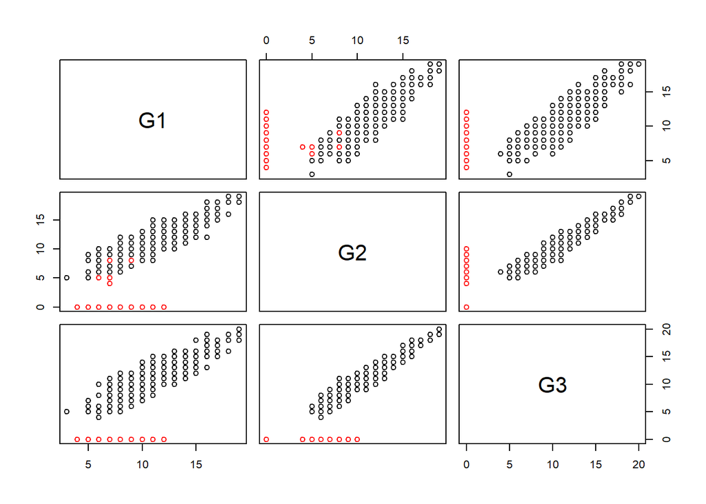

The coloring in the plot was determined by if the G3 column in our data set was equal to zero. The red points represent students who dropped out of the class before the end of the year. This trend lead us to the focus of our report: What variables have an effect on whether a student will drop out?

This question is important to ask since if we can identify which students are most likely to drop out then analysis can be done on future students and those students who are predicted to be most likely in danger of dropping out can receive access to additional resources and assistance. This is especially important to our data set when the Portuguese are trying to improve there student failure rate in core classes. Our data set shows that at the time of data collection there was about a 10% drop out rate which is very high.

| completedCourse | count | freq |
| --- | --- | --- |
| FALSE | 38 | 9.62% |
| TRUE | 357 | 90.38% |

# Report

We started off by transforming our data and adding two columns “dropped” and “completedCourse.” “dropped” and “completedCourse” were equivalent in meaning, whether a student ended with a final grade, G3, of zero indicating they dropped out and did not complete the course. G1, G2, and G3 were transformed into percentage values with 20 being the highest possible grade.

Through various trials of distribution analysis, our group came to the conclusion that the study used was too small of a sample size to show any sufficient distribution. Also, we noticed that - outside of the obvious stand-outs (G1, failures) - there wasn’t enough significance among the rest of the selected variables to answer questions about distribution via plotting. While creating a final model, a factor we found important was the direction in which the variables had affects on drop out rates. For example, success in G1 negatively impacts the dropout rate, but having a romantic life positively impacts the dropout rate. We gave emphasis to this directional analysis due to the future questions it would produce down the road if further studies were desired.

We improved the model by using stepwise selection according to AIC.

```
##
## Call:
## glm(formula = dropped ~ G1 + school + age + Fedu + traveltime +
##     failures + schoolsup + paid + romantic + Walc + absences,
##     data = drop2)
##
## Deviance Residuals:
##      Min        1Q    Median        3Q       Max
## -0.55842  -0.13990  -0.05657   0.04737   0.82635
##
## Coefficients:
##               Estimate Std. Error t value Pr(>|t|)
## (Intercept)   0.131310   0.209842   0.626 0.531847
## G1           -0.604770   0.085583  -7.066 7.56e-12 ***
## schoolMS     -0.112587   0.044768  -2.515 0.012316 *
## age           0.021547   0.011823   1.822 0.069160 .
## Fedu          0.017383   0.012418   1.400 0.162368
## traveltime    0.027615   0.019252   1.434 0.152276
## failures      0.053523   0.019581   2.733 0.006558 **
## schoolsupyes -0.145585   0.040774  -3.571 0.000402 ***
## paidyes      -0.069508   0.026171  -2.656 0.008239 **
## romanticyes   0.078549   0.027746   2.831 0.004885 **
## Walc         -0.030992   0.010327  -3.001 0.002866 **
## absences     -0.010192   0.001674  -6.089 2.77e-09 ***
## ---
## Signif. codes:  0 '***' 0.001 '**' 0.01 '*' 0.05 '.' 0.1 ' ' 1
##
## (Dispersion parameter for gaussian family taken to be 0.06383194)
##
##     Null deviance: 34.344  on 394  degrees of freedom
## Residual deviance: 24.448  on 383  degrees of freedom
## AIC: 47.932
##
## Number of Fisher Scoring iterations: 2
```

# Conclusion

We discovered that the variables with the largest impact were variables that rely on grades. This makes logical sense, because the grades are recorded throughout the semester. The grades will be relatively consistent- a student couldn’t go from failing to a perfect score. This also means that if a student has failures, this will impact grades. Our analysis proved this, which helps us show that our analysis makes sense. We discovered if a student had failed a class, they were more likely to drop out. If a student has higher grades, they were less likely to fail out. A suprising discovery an impactful factor in if a student is in a relationship, they are at high risk for dropping out. Maybe there is some merit in parents having rules about not dating in high school! Two other factors that impact if a student will drop out is if the student is recieving extra support from the school, and if a student takes extra paid classes within the course subject. Thankfully, these variables showed that if a student is recieving help, they are less likely to drop out.

If we had more time, resources, funding, etc, there are a few ways we would expand this project, and answer some further questions. First, an issue we found was because this sample was not very large and very specific, this means we could not draw accurate conclusions to apply our findings to other groups. We also could not find many significant variables, and part of this could be due to the lack of participants. Another issue is with the way the research was conducted. A few varibles were measured by students answering a range from 1-5 (1 being the lowest, 5 the highest) about some of their habits. For instance, instead of asking how many days a week do students consume alcohol or how many standard drinks do they consume, they ask students do rate themselves basically. This is not very standardized and more standardized questions would likely lead to better results. Another aspect to consider if the study was expanded is ensuring the curriculum is similar. For instance, if this study expanded to a variety of countries in Europe, then measuring grades in Portuguese might not be the best idea. We came up with a few questions that could be investigated further: How would our findings change if the study was expanded upon? Would different areas of the world have different results? If we could identify students that are at heightened risk for dropping out and provide them extra resources, would that be benefical? Would that be ethical? What factors should educators be aware of when it comes to preventing students from dropping out? What are the most cost effective ways to prevent students from dropping out? What behaviors should parents be concerned about with their child tha tcould increase their risk of droppping out?

We were able to come to a few conclusions, but not many based on our analysis. We tried a variety of methods to investigate our initial question of what variables have an effect on whether a student will drop out or not? All in all, we conducted a through analysis, but could find some more impactful solutions if we had more resources and data.